# Statistical Rethinking

Magnus Gasslander

Excercises from the Statistical Rethinking book

```r
library(rethinking)
```

## 2E1

$$Pr(rain|Monday)$$

## 2E2

The probability that it is Monday, given that it is raining.

## 2E3

$$Pr(Monday|rain)$$

and

$$Pr(rain|Monday)*Pr(Monday) / Pr(rain)$$

## 2E4

It is just our small world that deals with propabilities. In the real world there are no probabilities only truth

## 2M1

1 (W,W,W)

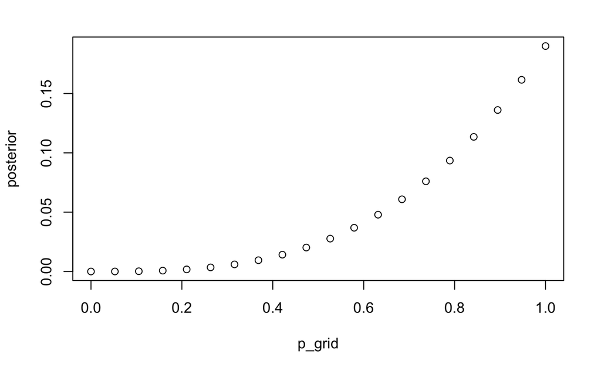

```r
p_grid <- seq(from = 0, to = 1, length.out = 20)
prior <- rep(1,20)
likelihood <- dbinom(x = 3, size = 3, prob = p_grid)
unstd.posterior <- likelihood * prior
posterior <- unstd.posterior / sum(unstd.posterior)
plot(p_grid,posterior)
```

2 (W,W,W,L)

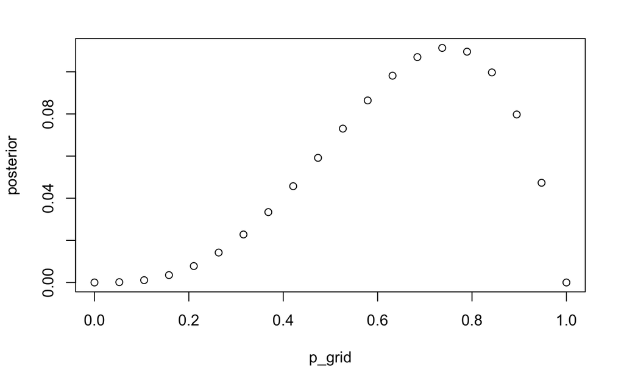

```r
p_grid <- seq(from = 0, to = 1, length.out = 20)
prior <- rep(1,20)
likelihood <- dbinom(x = 3, size = 4, prob = p_grid)
unstd.posterior <- likelihood * prior
posterior <- unstd.posterior / sum(unstd.posterior)
plot(p_grid,posterior)
```

3 (L,W,W,L,W,W,W)

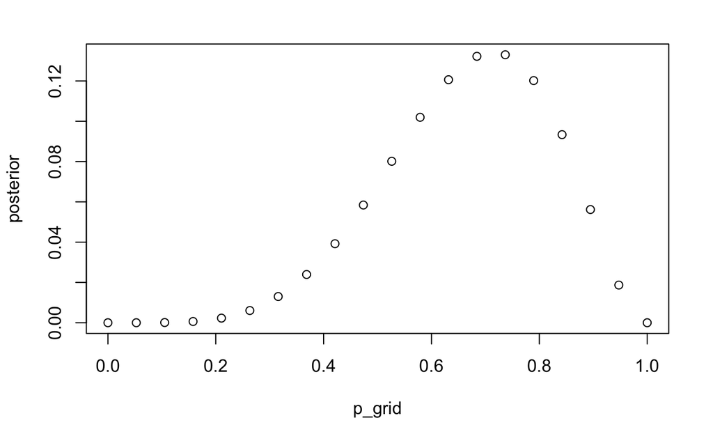

```r
p_grid <- seq(from = 0, to = 1, length.out = 20)
prior <- rep(1,20)
likelihood <- dbinom(x = 5, size = 7, prob = p_grid)
unstd.posterior <- likelihood * prior
posterior <- unstd.posterior / sum(unstd.posterior)
plot(p_grid,posterior)
```

## 2M2

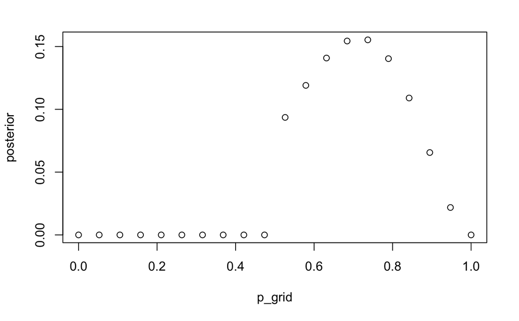

```r
p_grid <- seq(from = 0, to = 1, length.out = 20)
prior <- ifelse(p_grid < 0.5,0,1)
likelihood <- dbinom(x = 5, size = 7, prob = p_grid)
unstd.posterior <- likelihood * prior
posterior <- unstd.posterior / sum(unstd.posterior)
plot(p_grid,posterior)
```

## 2M3

Show that $Pr(Earth|Land) = .23$

$$Pr(Earth|Land) = \frac {Pr(Land|Earth)*Pr(Earth)} {Pr(Land)}$$

```r
.3 * .5 /(.5*1 + .5*.3)
```

```
[1] 0.2307692
```

.3 * .5 / 0.65 = 0.23

## 2M4

BB BB BW WB WW WW

There are three ways to choose a B front card. 2 of those has a black back side

p(BB|B) = 2/3

## 2M5

BB BB BB BB BW WB WW WW

There are 5 ways to choose a black front. 4 of those have a black back side

P(BB|B) = 4/5

## 2M6

BB BB (below twice as common as BB) BW BW WB WB (below 3 times as common as BB) WW WW WW WW WW WW

There are 4 ways to pull a B front side card. Of those there are 2 ways to get a black back side

## 2M7

BB -> -BW +WB +WW +WW

BB -> -BW +WB +WW +WW

BW -> -BB -BB +WW +WW

WB -> -BB -BB +WW +WW

WW -> -BB -BB -BW +WB

WW -> -BB -BB -BW +WB

There are total 8 options to pull a B front then a white front.

6 of those have the BB card

p(B front, W front) = 6/8 = 3/4 = .75

## 2H1

$$p(twins, twins) = p(A|twins)*p(twins|A) + p(B|twins)*p(twins|B)$$

$$p(twins, twins) = (1/3)*.1 + (2/3)*.2$$

```r
p_twins_twins <- (1/3)*.1 + (2/3)*.2
p_twins_twins
```

```
[1] 0.1666667
```

## 2H2

$$p(A|twins) = \frac {p(twins/A) * p(A)} {p(twins)}$$

```r
p_A_twins <- .1*.5 / (.1*.5 + .2*.5)
p_A_twins
```

```
[1] 0.3333333
```

## 2H3

calculate $P(twins, single)$

$$p(A|twins, single) = \frac {p(twins, single|A)* p(A)} {p(twins, single)}$$

$$p(A|twins, single) = .1*.9*.5 / .1*.9*.5 + .2*.8*.5$$

```r
p_A_twins_single <- .1*.9*.5 / (.1*.9*.5 + .2*.8*.5)
p_A_twins_single
```

```
[1] 0.36
```

Alternative method using p(A|twins) as prior

$$p(A|twins, single) =\frac{ p(single|A) * p(A|twins)} {p(single)}$$

prior = p(At) = p(A|twins)

$$p(A|twins, single) = \frac {p(single|A)*p(At)} {p(single|A)*p(At) + p(single|B) * p(Bt)}$$

$$p(A|twins, single) = .9 * (1/3)/(.9*(1/3) + .8*(2/3))$$

```r
p_A_twins_single <- .9*(1/3)/(.9*(1/3) + .8*(2/3))
p_A_twins_single
```

```
[1] 0.36
```

## 2H4

$$p(Atest|A) = .8$$
$$p(Btest|B) = .65$$

$$p(A|Atest) = \frac {p(Atest|A)*p(A)} {p(Atest|A)*p(A) + p(Atest|B)*p(B)}$$

```r
p_A_Atest <- .8*.5/(.8*.5 + .35*.5)
p_A_Atest
```

```
[1] 0.6956522
```

### 2H4(2)

$$\frac {p(Atest|A)*p(A)} {p(Atest|A)*p(A) + p(Atest|B)*p(B)}$$

```r
#Hm, check
p_A_Atest_update <- .8*.36/(.8*.36 + .35*.64)
p_A_Atest_update
```

```
[1] 0.5625
```

# Chapter 3

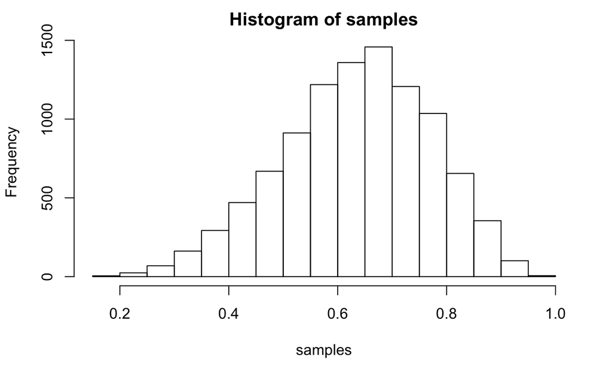

```r
p_grid <- seq(from = 0, to = 1, length.out = 1000)
prior <- rep (1, 1000)
likelihood <- dbinom (6, size = 9, prob = p_grid)
posterior <- likelihood * prior
posterior <- posterior / sum(posterior)
set.seed(100)
samples <- sample(p_grid, prob = posterior, size = 1e4, replace = TRUE)
hist(samples)
```

## 3E1

```r
sum(samples < .2) / 1e4
```

```
[1] 5e-04
```

## 3E2

```r
sum(samples > .8) / 1e4
```

```
[1] 0.1117
```

## 3E3

```r
sum(samples < .8 & samples > .2) / 1e4
```

```
[1] 0.8878
```

## 3E4

```r
quantile(samples, .2)
```

```
      20%
0.5195195
```

## 3E5

```r
d <- quantile(samples, .8)
d
```

```
      80%
0.7567568
```

## 3E6

```r
HPDI(samples, .66)
```

```
    |0.66     0.66|
0.5205205 0.7847848
```

## 3E7

```r
quantile(samples , c(.17, .83))
```

```
      17%       83%
0.5005005 0.7687688
```

```r
PI(samples , .66)
```

```
      17%       83%
0.5005005 0.7687688
```

## 3M1

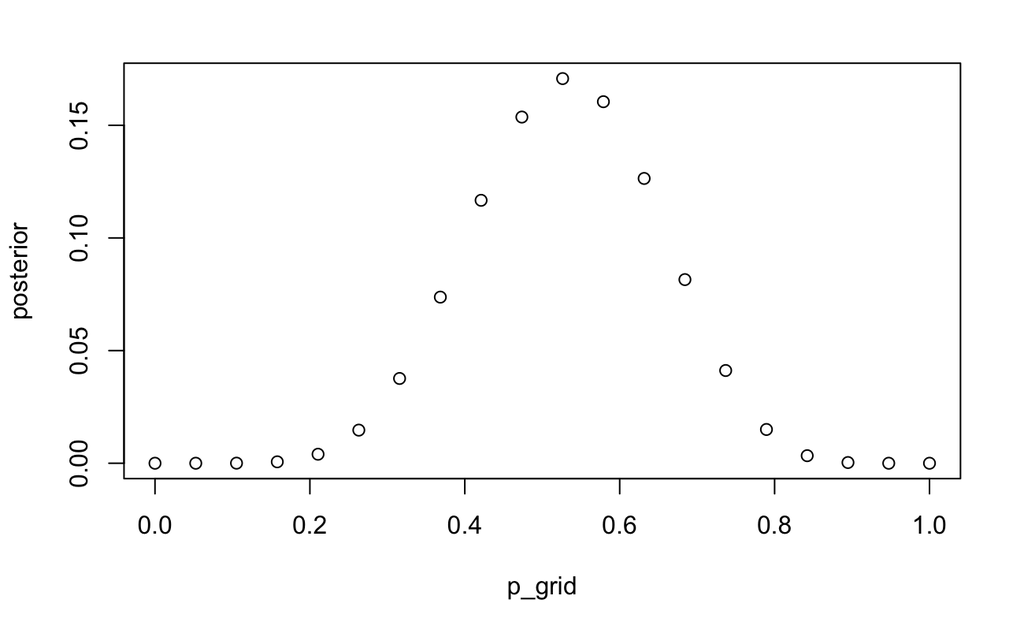

```r
p_grid <- seq(from = 0, to = 1, length.out = 20)
prior <- rep(1,20)
likelihood <- dbinom(x = 8, size = 15, prob = p_grid)
unstd.posterior <- likelihood * prior
posterior <- unstd.posterior / sum(unstd.posterior)
plot(p_grid,posterior)
```

## 3M2

```r
samples <- sample(p_grid, prob = posterior, size = 1e4, replace = TRUE)
HPDI(samples, .9)
```

```
     |0.9      0.9|
0.3157895 0.6842105
```

## 3M3

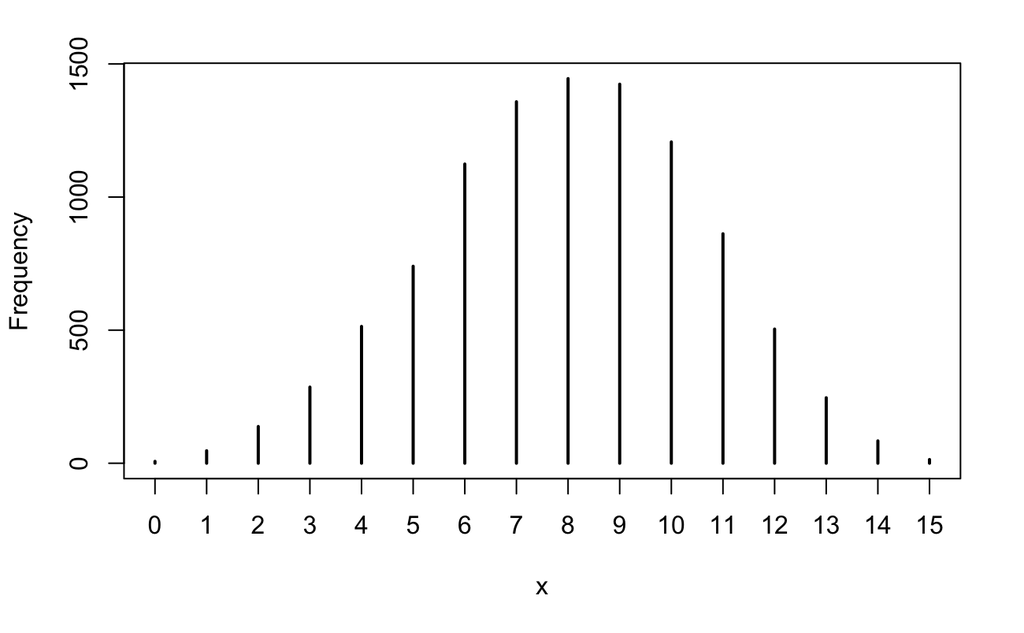

```r
w <- rbinom(10000, size=15, prob = samples)
simplehist(w)
```

```r
prob_8 <- sum(w == 8) / 1e4
prob_8
```

```
[1] 0.1445
```

## 3M4

```r
w9 <- rbinom(10000, size=9, prob = samples)
prob_6 <- sum(w9 == 6) / 10000
prob_6
```

```
[1] 0.1726
```

## 3M5

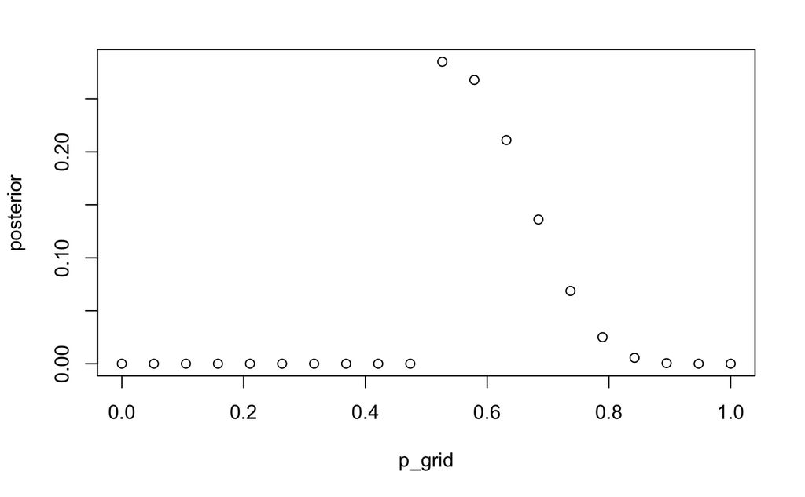

```r
p_grid <- seq(from = 0, to = 1, length.out = 20)
prior <- c(rep(0,10), rep(1,10))
likelihood <- dbinom(x = 8, size = 15, prob = p_grid)
unstd.posterior <- likelihood * prior
posterior <- unstd.posterior / sum(unstd.posterior)
plot(p_grid,posterior)
```

```r
samples <- sample(p_grid, prob = posterior, size = 1e4, replace = TRUE)
HPDI(samples, .9)
```

```
     |0.9      0.9|
0.5263158 0.6842105
```

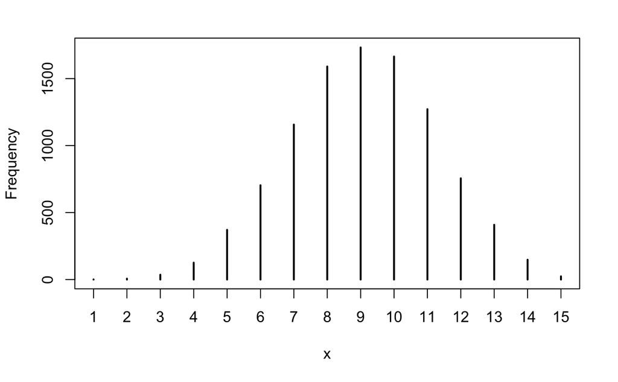

```r
w <- rbinom(10000, size=15, prob = samples)
simplehist(w)
```

```r
prob_8 <- sum(w == 8) / 1e4
prob_8
```

```
[1] 0.1591
```

```r
w9 <- rbinom(10000, size=9, prob = samples)
prob_6 <- sum(w9 == 6) / 10000
prob_6
```

```
[1] 0.2373
```

## 3H1

```r
library(rethinking)
data(homeworkch3)
sum(birth1) + sum(birth2)
```

```
[1] 111
```

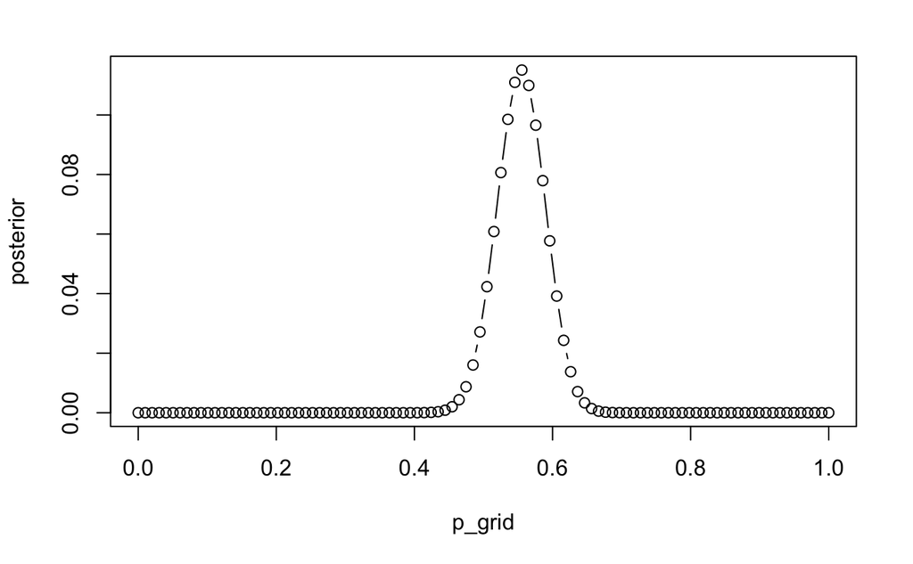

```r
p_grid <- seq(from = 0, to = 1, length.out = 100)
prior <- rep(1, 100)
likelihood <- dbinom (111, size = 200, prob = p_grid)
unstd.posterior <- likelihood * prior
posterior <- unstd.posterior / sum(unstd.posterior)
plot(p_grid, posterior, type = "b" )
```

```r
p_grid[which.max(posterior)]
```

```
[1] 0.5555556
```

## 3H2

```r
samples <- sample(p_grid, size = 10000, replace = TRUE, prob = posterior)
HPDI(samples, prob= .5)
```

```
     |0.5      0.5|
0.5454545 0.5858586
```

```r
HPDI(samples, prob = .89)
```

```
    |0.89     0.89|
0.4949495 0.6060606
```

```r
HPDI(samples, prob = .97)
```

```
    |0.97     0.97|
0.4848485 0.6262626
```

## 3H3

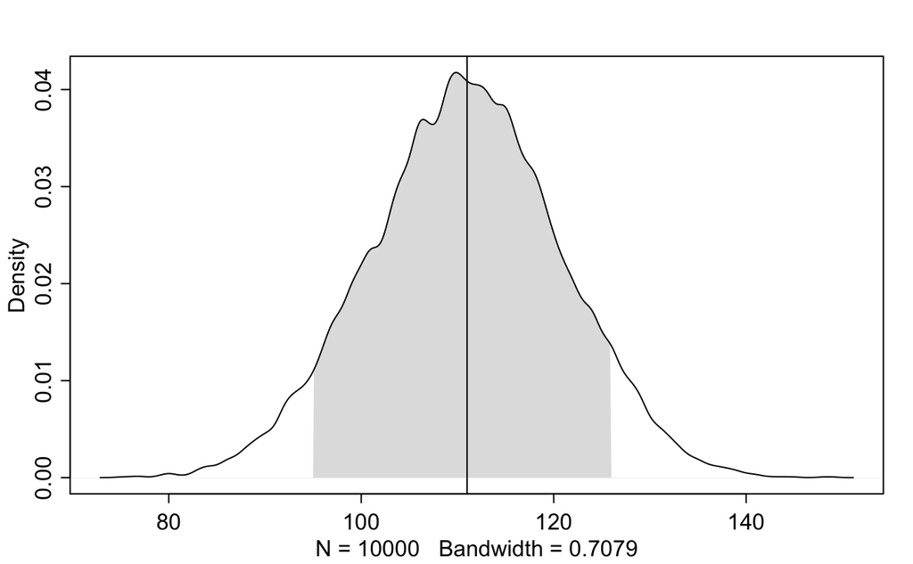

```r
s <- rbinom(10000, 200, samples)
#sampls <- data.frame(xx = c(s,samples), yy = rep(letters[1:2],each = 10000))
#ggplot(sampls, aes(x=xx, fill=yy)) + geom_histogram(position="identity", alpha=0.2)
dens(s, show.HPDI=.89)
abline(v=sum(c(birth1, birth2)))
```

The constructed posterior distribution is wider

## 3H4

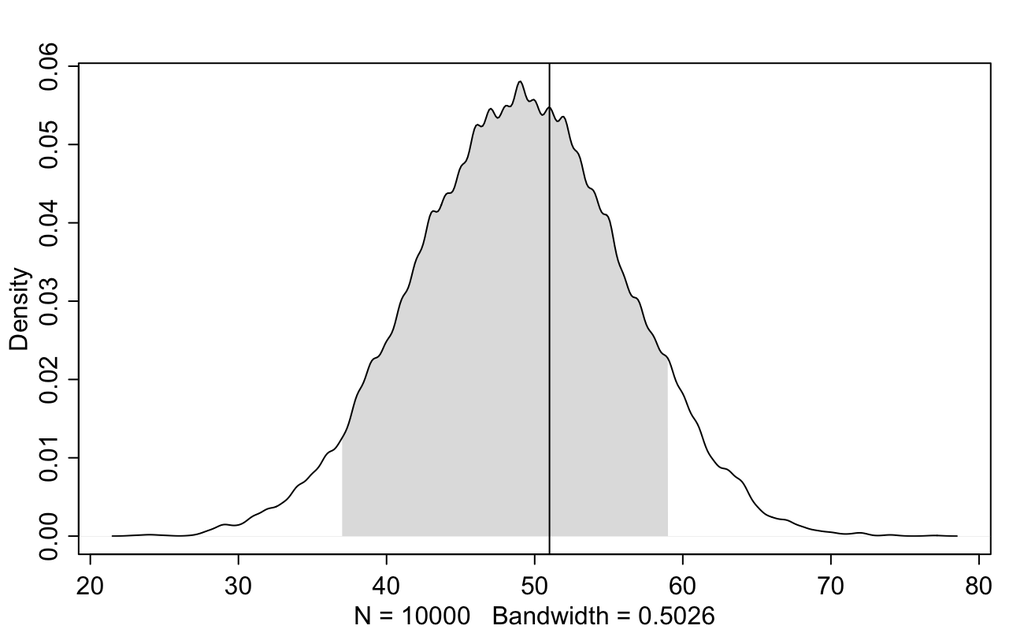

```r
s <- rbinom(10000, 100, samples)
#hist(s)
dens(s, show.HPDI=.89)
abline(v=sum(birth1))
```

## 3H5

Count number of first borns who were girls

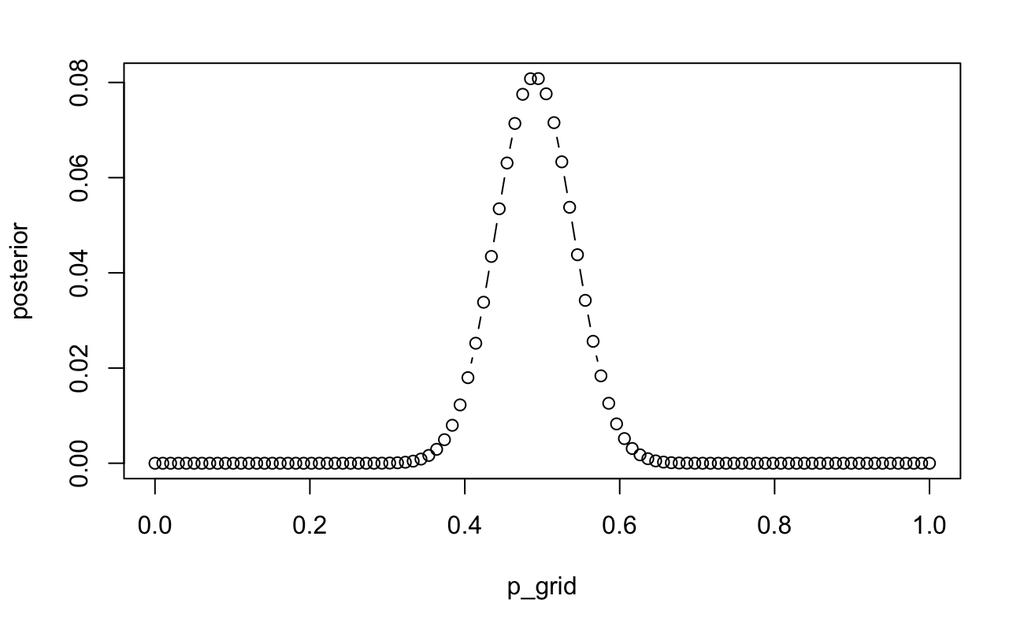

```r
first_born_girls <- sum(birth1 == 0)
p_grid <- seq(from = 0, to = 1, length.out = 100)
prior <- rep(1, 100)
likelihood <- dbinom (first_born_girls, size = 100, prob = p_grid)
unstd.posterior <- likelihood * prior
posterior <- unstd.posterior / sum(unstd.posterior)
plot(p_grid, posterior, type = "b" )
```

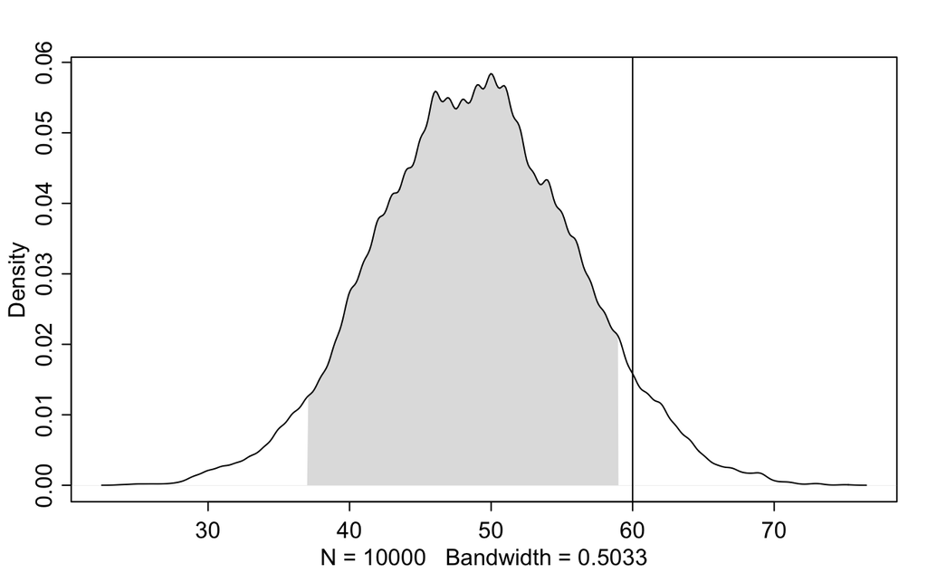

```r
samples <- sample(p_grid, size = 10000, replace = TRUE, prob = posterior)
s <- rbinom(10000, 100, samples)
dens(s, show.HPDI=.89)
abline(v=sum(birth2))
```

If they get a boy the first time they stop getting more children and then they will not be part of this group (hm, does this logic work?)